# Session 11 - Aligning graphics & ggplot2-extensions

Fabian Gülzau

18 Januar 2018

## Programm

1. ggplot2-Erweiterungen
2. Projekt
3. Ausblick
4. Grafiken kombinieren
5. Evaluation

## Wo stehen wir?

1. Datenaufbereitung
2. Grafikerstellung
3. Theorie & Empirie “guter Grafiken”
4. Nun: Erweiterungen und Anwendung (Projekt)

## ggplot2-Erweiterungen

- Hauptpaket: [ggplot2](http://ggplot2.tidyverse.org/)
- weitere Möglichkeiten:
1. weitere [Geoms](http://ggplot2.tidyverse.org/reference/index.html#section-layer-geoms) in ggplot2
2. [ggplot2-ext](http://www.ggplot2-exts.org/) mit Qualitätsprüfung
3. Weitere Pakete über CRAN/GitHub

## Exkurs: Pakete

CRAN:

- “Comprehensive R Archive Network” ([CRAN](https://cran.r-project.org/))
- Pakete sind geprüft und sicher
- Installation: `install.packages("ggplot2")`

GitHub:

- Softwareentwicklung (z.B. [Simon Munzert](https://github.com/simonmunzert))
- Pakete können geprüft werden (Paket: notary)
- Installation:

```r
install.packages("devtools")
library(devtools)

install_github("thomasp85/ggraph") # User/Repository (auf GitHub)
```

## Weitere geoms in ggplot2

Beispieldaten (Wahlergebnisse nach Bundesland) sind im Kurs verfügbar

```r
# Daten laden
vote.df <- readRDS(file = "C:/Users/User/HU-Box/Seafile/Meine Bibliothek/Seminare/WS 2017/Sessions/Session 10/VoteShare")

# Einen ersten Blick
glimpse(vote.df)
```

```
## Observations: 96
## Variables: 3
## $ land  <chr> "Baden-Würtemberg", "Baden-Würtemberg", "Baden-Würtember...
## $ party <chr> "CDU/CSU", "SPD", "AfD", "Grüne", "FDP", "Linke", "CDU/C...
## $ share <dbl> 34.4, 16.4, 12.2, 13.5, 12.7, 6.4, 38.8, 15.3, 12.4, 9.8...
```

## Heatmap

Heatmap ([geom_tile](http://ggplot2.tidyverse.org/reference/geom_tile.html)):

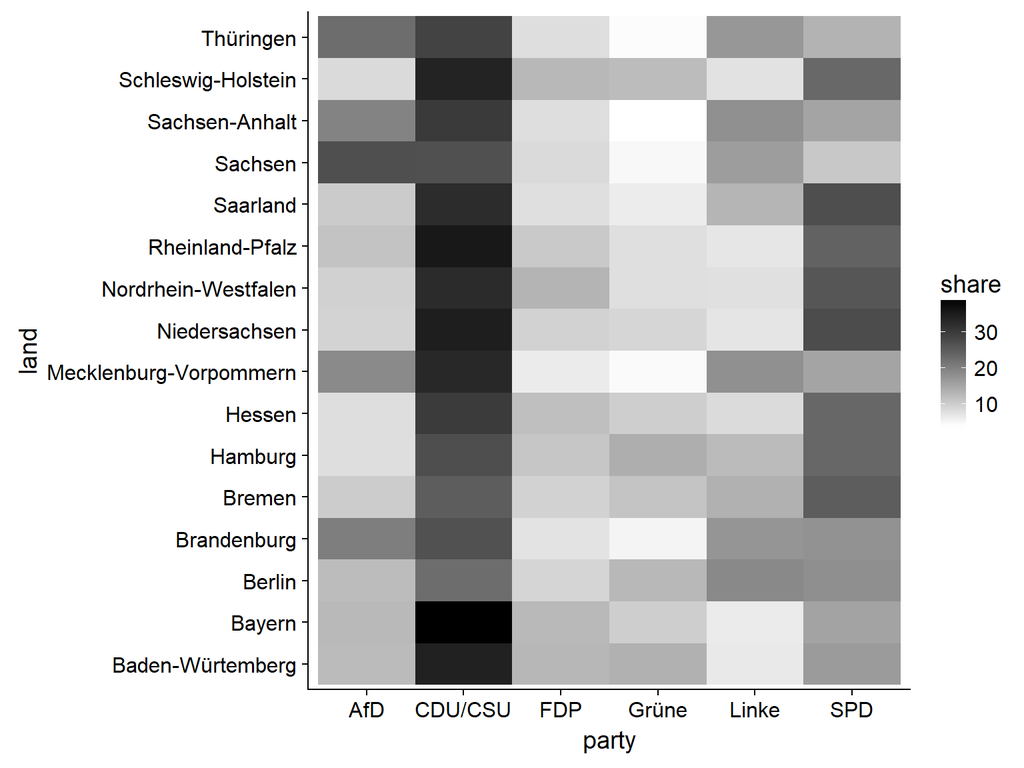

```r
ggplot(data = vote.df, mapping = aes(party, land)) +
  geom_tile(mapping = aes(fill = share)) +
  scale_fill_gradient(low = "white", high = "black")
```

## Grafiken hinterfragen

Eignet sich die Grafik gut zur Darstellung von wahlergebnissen über die einzelnen Bundesländer?

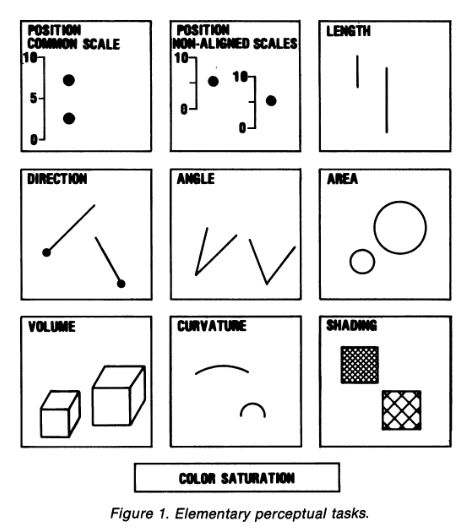

## Beispiele für ggplot2-ext

Beispieldaten (Visa Network Data)

```r
# Daten laden
visa.df <- readRDS(file = "C:/Users/User/HU-Box/Seafile/Meine Bibliothek/Seminare/WS 2017/Sessions/Session 2/VisaNetworkData_041017")

# Einen ersten Blick
glimpse(visa.df)
```

```
## Observations: 166
## Variables: 12
## $ name      <chr> "Afghanistan", "Albania", "Algeria", "Angola", "Arge...
## $ indegree  <dbl> 1, 12, 10, 5, 69, 14, 71, 76, 14, 20, 6, 17, 78, 17,...
## $ outdegree <dbl> 0, 47, 8, 1, 67, 10, 0, 58, 10, 5, 22, 11, 58, 25, 0...
## $ year      <dbl> 2010, 2010, 2010, 2010, 2010, 2010, 2010, 2010, 2010...
## $ polity2   <dbl> NA, 9, 2, -2, 8, 5, 10, 10, -7, -5, 5, -7, 8, 7, 3, ...
## $ iso3      <chr> "AFG", "ALB", "DZA", "AGO", "ARG", "ARM", "AUS", "AU...
## $ pop       <dbl> NA, 2.901883, 36.036159, 21.219954, 41.222875, 2.963...
## $ hc        <dbl> NA, 2.904078, 2.039871, 1.417133, 2.830078, 3.111228...
## $ cgdpe     <dbl> NA, 25962.809, 447539.500, 130088.281, 760271.875, 2...
## $ gdppc     <dbl> NA, 8946.8833, 12419.1787, 6130.4695, 18442.9610, 70...
## $ continent <chr> "Asia", "Europe", "Africa", "Africa", "Americas", "A...
## $ region    <chr> "Southern Asia", "Southern Europe", "Northern Africa...
```

## ggalt::geom_lollipop

Welche sind die größten Gewinner und Verlierer bzgl. Reisefreiheit?

Beispiel: Top10/Flop10 bzgl. Reisefreiheit (`indegree`)

- Paket: `ggalt`
- `install.packages("ggalt)`
- `devtools::install_github("hrbrmstr/ggalt")`

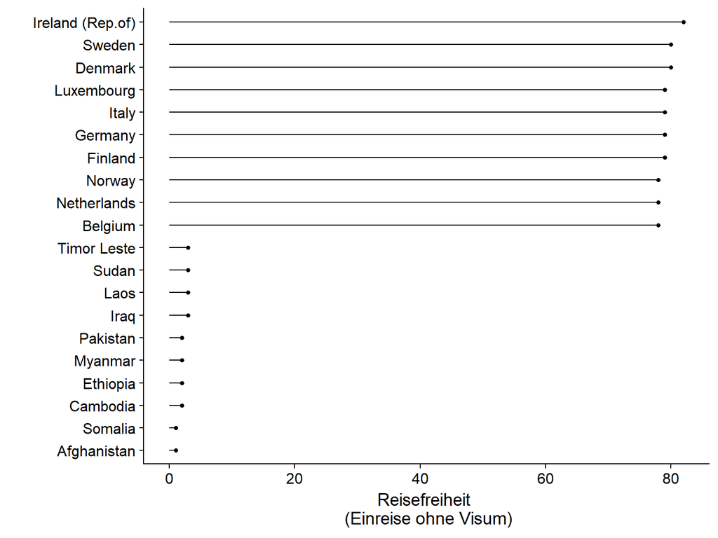

## Projekt

1. Gruppen (2-3 Personen)
2. Eigene Visualisierung oder Rekonstruktion (Originaldaten müssen nicht vorliegen)
- Daten aus dem Kurs (Visa Network Data, Nobelpreis, Pokemon…)
- Grafiken aus Zeitungen oder Online
3. Inkl. Bezug zur Theorie (Tufte; Cairo; Cleveland & McGill)

Abgabe: **12. Februar 2018**

## Ausblick

```r
library(ggraph)
library(igraph)
```

Daten formatieren ([igraph](http://igraph.org/r/doc/aaa-igraph-package.html)):

```r
visa <- readRDS(file = "C:/Users/User/HU-Box/Seafile/Meine Bibliothek/Seminare/WS 2017/Sessions/Session 10/VisaMatrix")

# (1) Matrixrepräsentation
visa.mat <- as.matrix(visa)

# (2) Netzwerkfunktionalität über "igraph"
visa.graph <- igraph::graph_from_adjacency_matrix(visa.mat, mode = "directed",
                                             diag = FALSE, add.colnames = TRUE)
```

## Beispiele: ggraph

Netzwerkgrafiken:

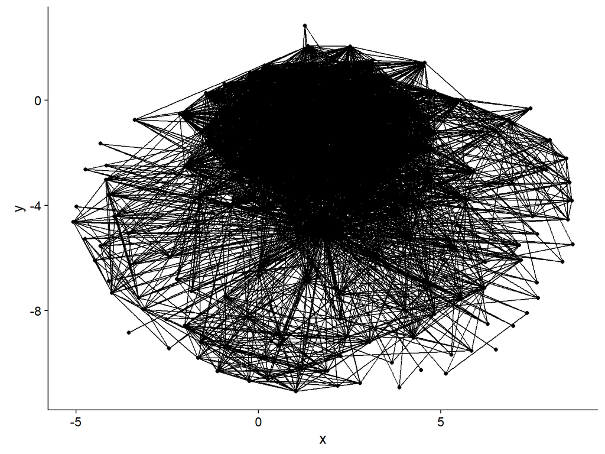

```r
visa.plot <- ggraph(visa.graph, layout = "kk") + # Layout
  geom_edge_link() +                             # Edges
  geom_node_point()                              # like geom_point

visa.plot
```

## Ausblick: Offene Sitzung

- ggraph
- [ShinyR](https://shiny.rstudio.com/gallery/movie-explorer.html)
- [Animationen](https://github.com/dgrtwo/gganimate/blob/master/README/README-fig-unnamed-chunk-3-.gif)
- Weitere Ideen?

## Grafiken kombinieren

Kombination von Grafiken etwa in:

- Informationgrafiken ([Cairo 2013: The Functional Art](http://www.thefunctionalart.com/))
- Beschreibungen von Samples ([Kastellec & Leoni 2007](https://www.cambridge.org/core/services/aop-cambridge-core/content/view/S1537592707072209))

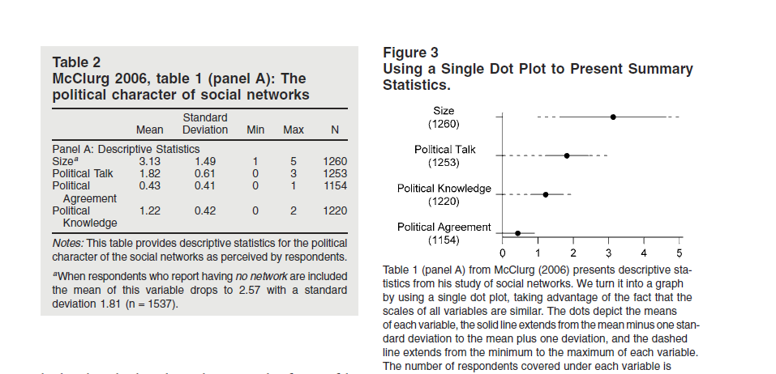

## Grafiken kombinieren


## Grafiken kombinieren

Nehmen wir die Top10 und Flop10 aus der heutigen Sitzung:

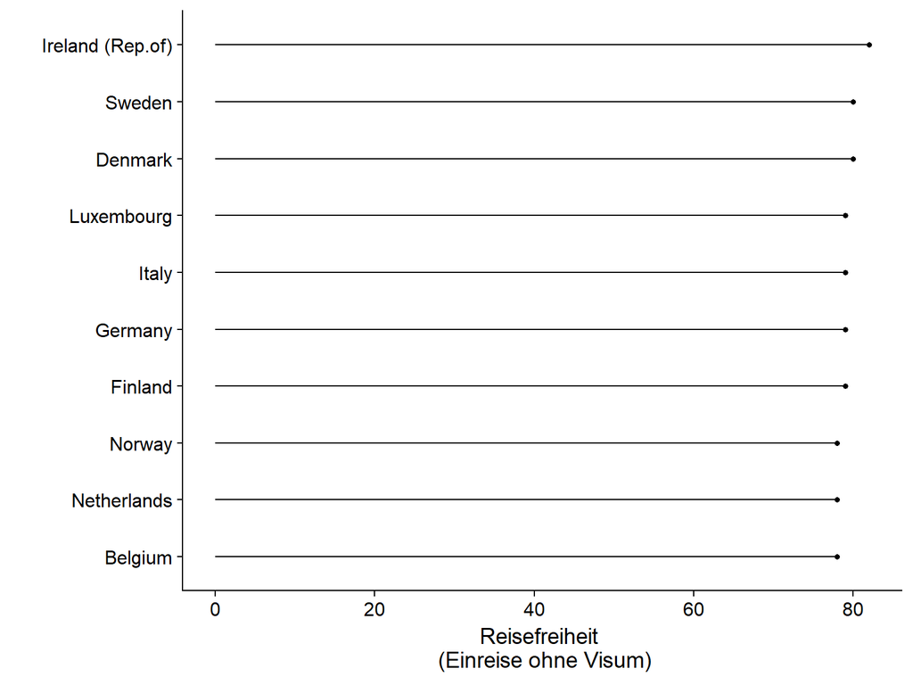

```r
top10.fig <- ggplot(data = top10, mapping = aes(x = reorder(name, indegree), y = indegree))+
  geom_lollipop() +
  labs(x = "", y = "Reisefreiheit \n (Einreise ohne Visum)") +
  coord_flip()

flop10.fig <- ggplot(data = flop10, mapping = aes(x = reorder(name, indegree), y = indegree))+
  geom_lollipop() +
  labs(x = "", y = "Reisefreiheit \n (Einreise ohne Visum)") +
  scale_y_continuous(limits = c(0, 82)) +
  coord_flip()

top10.fig
```

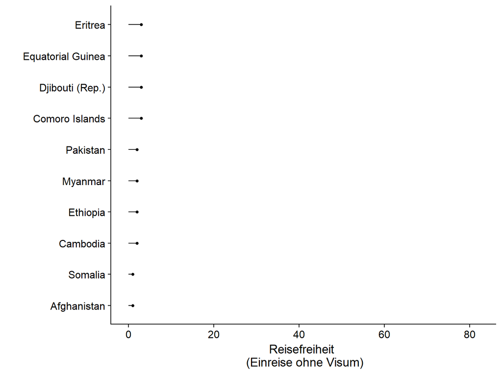

```r
flop10.fig
```

## Paket: Cowplot I

Beispiel (`?plot_grid`):

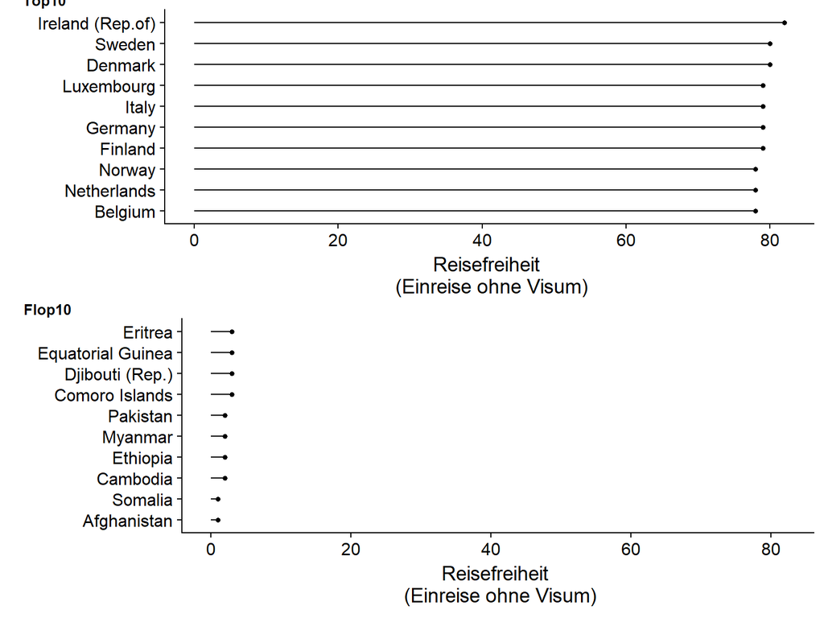

```r
library(cowplot)

plot_grid(top10.fig, flop10.fig, labels = c("Top10", "Flop10"), nrow = 2, vjust = .5,
          label_size = 10)
```

Oft lassen sich ähnliche Grafiken aber auch mit `facet_wrap()` erstellen.

## Paket: Cowplot II

Beispiel:

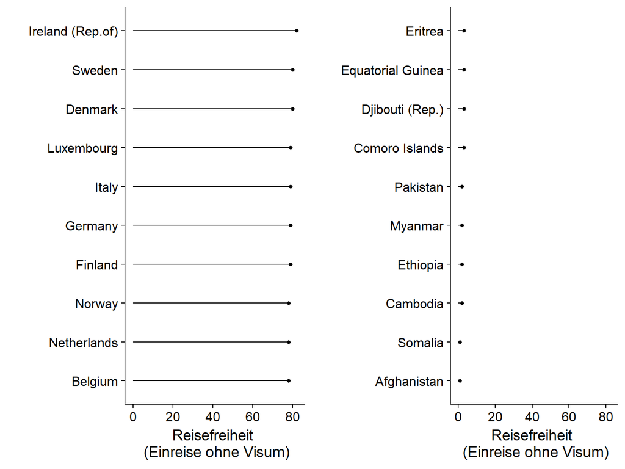

```r
library(cowplot)

plot_grid(top10.fig, flop10.fig, ncol = 2)
```

Oft lassen sich ähnliche Grafiken aber auch mit `facet_wrap()` erstellen.

## Komplexere Anordnungen mit Cowplot

Komplexere Anordnungen lassen sich über `ggdraw` und `draw_plot` erstellen:

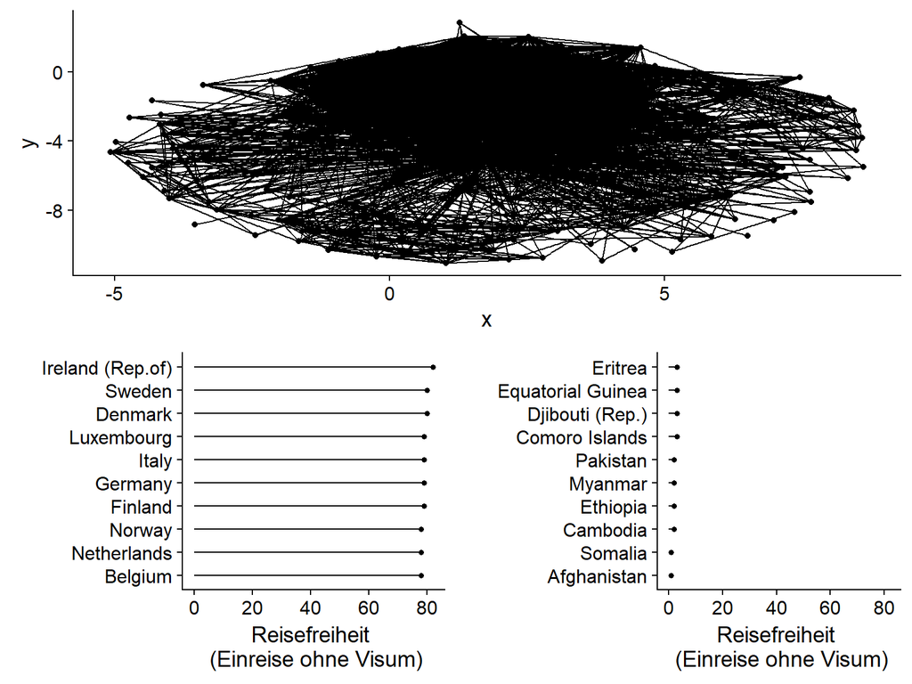

```r
ggdraw() +
  draw_plot(visa.plot, x = 0, y = .5, width = 1, height = .5) +
  draw_plot(top10.fig, x = 0, y = 0, width = .5, height = .5) +
  draw_plot(flop10.fig, x = .5, y = 0, width = .5, height = .5)
```

## Das Anscombe-Quartett

Das Anscombe-Quartett ([Anscombe(1973)](https://www.jstor.org/stable/2682899?seq=1#page_scan_tab_contents)) ist ein bekanntes Beispiel für die Notwendigkeit explorativer Datenanalyse und -visualisierung.

```r
data(anscombe) # in R verfügbar
glimpse(anscombe)
```

```
## Observations: 11
## Variables: 8
## $ x1 <dbl> 10, 8, 13, 9, 11, 14, 6, 4, 12, 7, 5
## $ x2 <dbl> 10, 8, 13, 9, 11, 14, 6, 4, 12, 7, 5
## $ x3 <dbl> 10, 8, 13, 9, 11, 14, 6, 4, 12, 7, 5
## $ x4 <dbl> 8, 8, 8, 8, 8, 8, 8, 19, 8, 8, 8
## $ y1 <dbl> 8.04, 6.95, 7.58, 8.81, 8.33, 9.96, 7.24, 4.26, 10.84, 4.82...
## $ y2 <dbl> 9.14, 8.14, 8.74, 8.77, 9.26, 8.10, 6.13, 3.10, 9.13, 7.26,...
## $ y3 <dbl> 7.46, 6.77, 12.74, 7.11, 7.81, 8.84, 6.08, 5.39, 8.15, 6.42...
## $ y4 <dbl> 6.58, 5.76, 7.71, 8.84, 8.47, 7.04, 5.25, 12.50, 5.56, 7.91...
```

Welchen Eindruck gewinnen wir durch deskriptive Maße des Datensatzen (Mittelwert, SD)?

## Das Anscombe-Quartett

Regressionsanalyse:

```r
x <- with(anscombe,
          list(x1, x2, x3,x4))

y <- with(anscombe,
          list(y1, y2, y3, y4))

# Vier lineare Regressionen (Loop)
map2(.x = x, .y = y, .f = ~ lm(.y ~ .x))
```

```
## [[1]]
##
## Call:
## lm(formula = .y ~ .x)
##
## Coefficients:
## (Intercept)           .x
##      3.0001       0.5001
##
##
## [[2]]
##
## Call:
## lm(formula = .y ~ .x)
##
## Coefficients:
## (Intercept)           .x
##       3.001        0.500
##
##
## [[3]]
##
## Call:
## lm(formula = .y ~ .x)
##
## Coefficients:
## (Intercept)           .x
##      3.0025       0.4997
##
##
## [[4]]
##
## Call:
## lm(formula = .y ~ .x)
##
## Coefficients:
## (Intercept)           .x
##      3.0017       0.4999
```

## Das Anscombe-Quartett

Grafische Darstellung (Scatterplot):

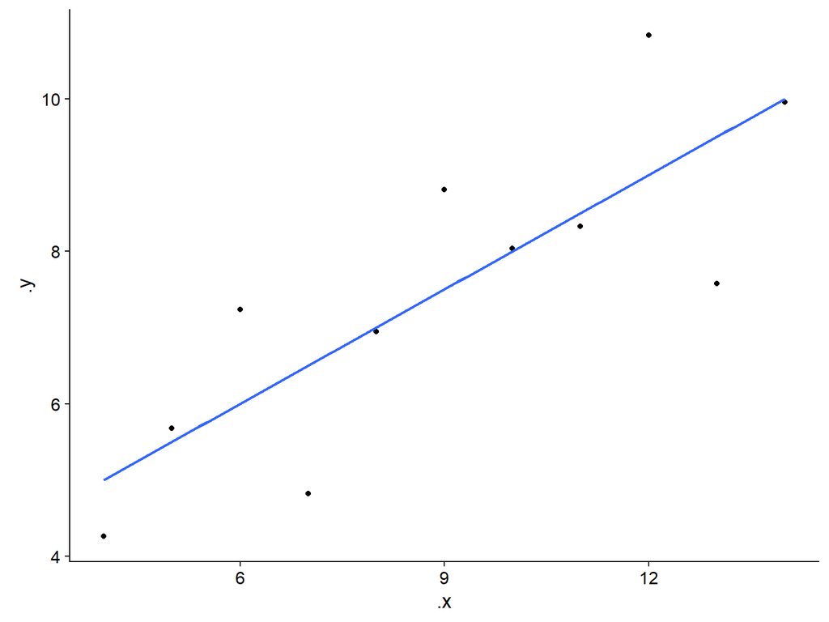

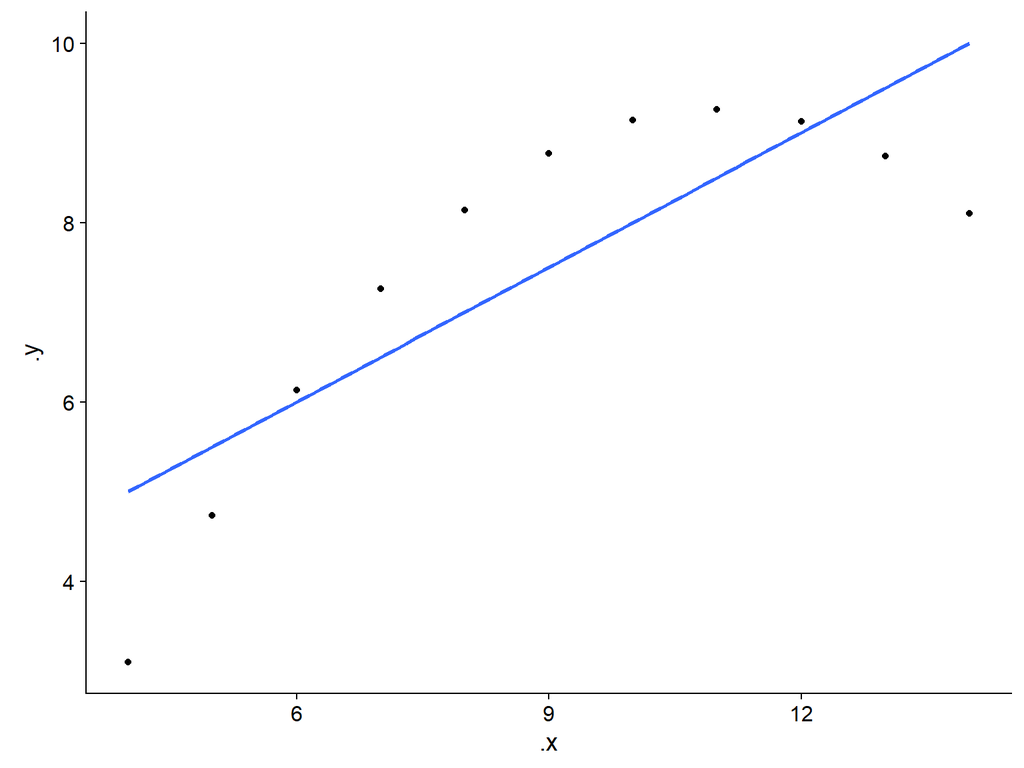

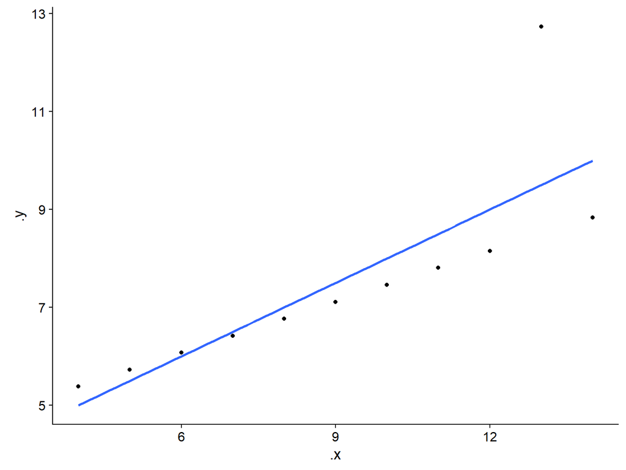

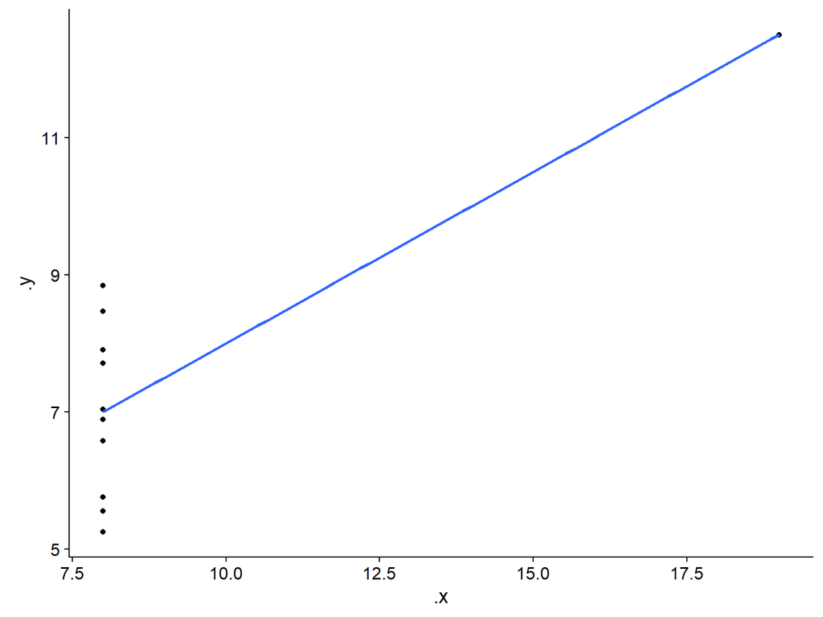

```r
scatter <- map2(.x = x, .y = y,
                .f = ~ ggplot() +
    geom_point(mapping = aes(x = .x, y = .y)) +
      geom_smooth(mapping = aes(x = .x, y = .y), method = "lm", se = FALSE)
)

scatter
```

## Das Anscombe-Quartett (Anordnung)

Könnt ihr die Grafiken mit Hilfe von `cowplot::plot_grid` derartig anordnen?

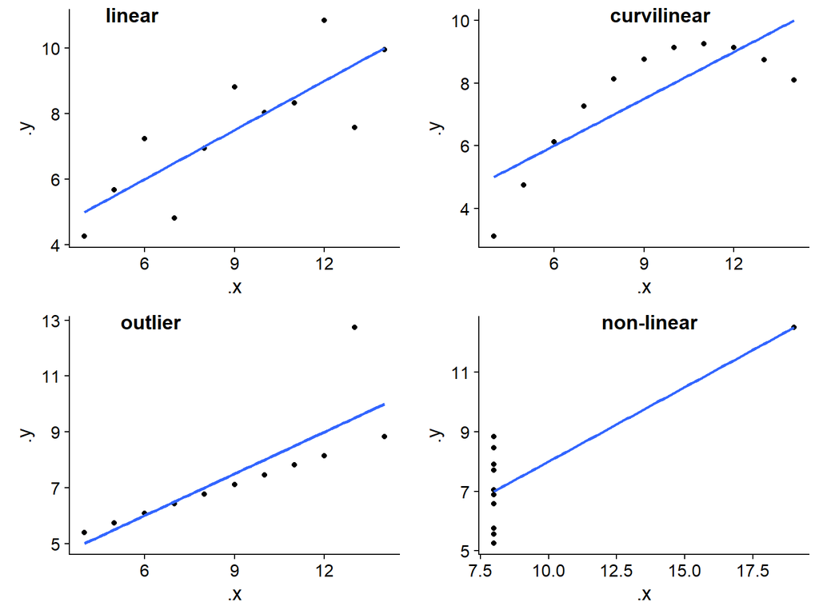

## Evaluation

Der Kurs wird das erste Mal angeboten, weshalb Feedback sehr hilfreich ist, um den Kurs weiter zu entwickeln. Vielen Dank.